# Analysis of the impact on health and economy for different types of events

2/20/2020

## Synopsis

Storms and other severe weather events can cause both public health and economic problems for communities and municipalities. Many severe events can result in fatalities, injuries, and property damage, and preventing such outcomes to the extent possible is a key concern.

This project involves exploring the U.S. National Oceanic and Atmospheric Administration’s (NOAA) storm database. This database tracks characteristics of major storms and weather events in the United States, including when and where they occur, as well as estimates of any fatalities, injuries, and property damage.

The data and documentation are available at the following links:

- [Storm Data](https://d396qusza40orc.cloudfront.net/repdata%2Fdata%2FStormData.csv.bz2)
- [National Weather Service Storm Data Documentation](https://d396qusza40orc.cloudfront.net/repdata%2Fpeer2_doc%2Fpd01016005curr.pdf)
- [National Climatic Data Center Storm Events FAQ](https://d396qusza40orc.cloudfront.net/repdata%2Fpeer2_doc%2FNCDC%20Storm%20Events-FAQ%20Page.pdf)

The target is to answer the following two questions:  
1. Across the United States, which types of events are most harmful with respect to population health?  
2. Across the United States, which types of events have the greatest economic consequences?

## Data Processing

First, all the libraries needed for the analysis are loaded, and some constants related to the source data file are set.

```r
## Dependencies
library(dplyr)
library(tidyr)
library(ggplot2)
library(RColorBrewer)

# Set constants
fileUrl <- "https://d396qusza40orc.cloudfront.net/repdata%2Fdata%2FStormData.csv.bz2"
zippedFileName <- "repdata_data_StormData.csv.bz2"
```

Then the file is downloaded, if necessary, and the data is read.

```r
# Downloading the raw data file, if necessary
if (!file.exists(zippedFileName)) {
  print("Downloading the file...")
  download.file(fileUrl, destfile = zippedFileName, method = "curl")
}

# Reading the data
con <- bzfile(zippedFileName, open = "r")
stormData <- read.csv(con)
close(con)
```

The column names are displayed to get an overview of what is inside the dataset.

```r
colnames(stormData)
```

```
##  [1] "STATE__"    "BGN_DATE"   "BGN_TIME"   "TIME_ZONE"  "COUNTY"
##  [6] "COUNTYNAME" "STATE"      "EVTYPE"     "BGN_RANGE"  "BGN_AZI"
## [11] "BGN_LOCATI" "END_DATE"   "END_TIME"   "COUNTY_END" "COUNTYENDN"
## [16] "END_RANGE"  "END_AZI"    "END_LOCATI" "LENGTH"     "WIDTH"
## [21] "F"          "MAG"        "FATALITIES" "INJURIES"   "PROPDMG"
## [26] "PROPDMGEXP" "CROPDMG"    "CROPDMGEXP" "WFO"        "STATEOFFIC"
## [31] "ZONENAMES"  "LATITUDE"   "LONGITUDE"  "LATITUDE_E" "LONGITUDE_"
## [36] "REMARKS"    "REFNUM"
```

### Question 1: which types of events are most harmful with respect to population health?

To answer the first question, the total number of fatalities (column **FATALITIES**) and injuries (column **INJURIES**) are calculated with respect to the event type (column **EVTYPE**), and both totals are arranged in decreasing order in a Pareto fashion. Furthermore, only the first top 9 items are considered, and the rest is consolidated as **OTHERS**.

```r
# Fatalities
fatalities <- stormData %>%
  group_by(EVTYPE) %>%
  summarize(total_FATALITIES = sum(FATALITIES, na.rm = TRUE)) %>%
  arrange(desc(total_FATALITIES)) %>%
  mutate(EVTYPE = factor(EVTYPE, levels = c(as.character(EVTYPE), "OTHERS")))
fatalities <- rbind(fatalities[1:9,], c("OTHERS", sum(fatalities$total_FATALITIES[-1:-9]))) %>%
  mutate(total_FATALITIES = as.numeric(total_FATALITIES))

# Injuries
injuries <- stormData %>%
  group_by(EVTYPE) %>%
  summarize(total_INJURIES = sum(INJURIES, na.rm = TRUE)) %>%
  arrange(desc(total_INJURIES)) %>%
  mutate(EVTYPE = factor(EVTYPE, levels = c(as.character(EVTYPE), "OTHERS")))
injuries <- rbind(injuries[1:9,], c("OTHERS", sum(injuries$total_INJURIES[-1:-9]))) %>%
  mutate(total_INJURIES = as.numeric(total_INJURIES))
```

### Question 2: which types of events have the greatest economic consequences?

To answer the second question, the total property damage (based on columns **PROPDMG** and **PROPDMGEXP**) and crop damage (based on columns **CROPDMG** and **CROPDMGEXP**) are calculated with respect to the event type (column **EVTYPE**). The total damage is calculated as the sum of the two, and it is arranged in decreasing order in a Pareto fashion. Furthermore, only the first top 9 items are considered, and the rest is consolidated as **OTHERS**.

```r
# Damage
damage <- stormData %>%
  mutate(PROPDMGFACT = ifelse(PROPDMGEXP == "B", 10^9,
                              ifelse(PROPDMGEXP %in% c("m", "M"), 10^6,
                                     ifelse(PROPDMGEXP %in% c("k", "K"), 10^3,
                                            ifelse(PROPDMGEXP == "h", 10^2, 1))))) %>%
  mutate(CROPDMGFACT = ifelse(CROPDMGEXP == "B", 10^9,
                            ifelse(CROPDMGEXP %in% c("m", "M"), 10^6,
                                   ifelse(CROPDMGEXP %in% c("k", "K"), 10^3,
                                          ifelse(CROPDMGEXP == "h", 10^2, 1))))) %>%
  mutate(PROPDAMAGE = PROPDMG * PROPDMGFACT, CROPDAMAGE = CROPDMGFACT * CROPDMG) %>%
  group_by(EVTYPE) %>%
  summarize(total_PROPDAMAGE = sum(PROPDAMAGE, na.rm = TRUE),
            total_CROPDAMAGE = sum(CROPDAMAGE, na.rm = TRUE)) %>%
  mutate(total_DAMAGE = total_PROPDAMAGE + total_CROPDAMAGE) %>%
  arrange(desc(total_DAMAGE)) %>%
  mutate(EVTYPE = factor(EVTYPE, levels = c(as.character(EVTYPE), "OTHERS")))
damage <- rbind(damage[1:9,], c("OTHERS", sum(damage$total_PROPDAMAGE[-1:-9]),
                                sum(damage$total_CROPDAMAGE[-1:-9]),
                                sum(damage$total_DAMAGE[-1:-9]))) %>%
  mutate(total_PROPDAMAGE = as.numeric(total_PROPDAMAGE),
         total_CROPDAMAGE = as.numeric(total_CROPDAMAGE),
         total_DAMAGE = as.numeric(total_DAMAGE))
```

*Note:* the columns **PROPDMGEXP** and **CROPDMGEXP** contain various symbols.

```r
table(stormData$PROPDMGEXP)
```

```
##
##             -      ?      +      0      1      2      3      4      5      6
## 465934      1      8      5    216     25     13      4      4     28      4
##      7      8      B      h      H      K      m      M
##      5      1     40      1      6 424665      7  11330
```

```r
table(stormData$CROPDMGEXP)
```

```
##
##             ?      0      2      B      k      K      m      M
## 618413      7     19      1      9     21 281832      1   1994
```

They are interpreted as value multipliers using the following rules:  
- **“B”** stands for **10^9**  
- **“m”** and **“M”** stand for **10^6**  
- **“k”** and **“K”** stand for **10^3**  
- **“h”** stands for **10^2**  
- **Everything else** stands for **1**

## Results

Based on the previous processing is now possible to answer the two questions.

### Question 1: which types of events are most harmful with respect to population health?

It’s possible to see from the tables and the charts that **TORNADO** is the event type causing the highest number of both fatalities and injuries. Moreover, also **EXCESSIVE HEAT** and **LIGHTNING** appear in the top-5 list of both fatalities and injuries.

```r
fatalities
```

```
## # A tibble: 10 x 2
##    EVTYPE         total_FATALITIES
##    <fct>                     <dbl>
##  1 TORNADO                    5633
##  2 EXCESSIVE HEAT             1903
##  3 FLASH FLOOD                 978
##  4 HEAT                        937
##  5 LIGHTNING                   816
##  6 TSTM WIND                   504
##  7 FLOOD                       470
##  8 RIP CURRENT                 368
##  9 HIGH WIND                   248
## 10 OTHERS                     3288
```

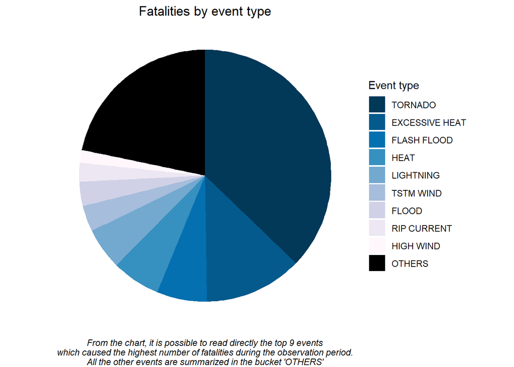

```r
ggplot(data = fatalities, aes(x = "", y = total_FATALITIES, fill = EVTYPE)) +
  geom_bar(stat="identity") + coord_polar("y", start = 0, direction = -1) +
  theme_void() + theme(plot.title = element_text(hjust = 0.5),
                       plot.caption=element_text(hjust = 0.5, face = "italic")) +
  scale_fill_manual(name = "Event type", values = c(rev(brewer.pal(9, "PuBu")), "#000000")) +
  labs(title = "Fatalities by event type",
  caption = "From the chart, it is possible to read directly the top 9 events
which caused the highest number of fatalities during the observation period.
All the other events are summarized in the bucket 'OTHERS'")
```

```r
injuries
```

```
## # A tibble: 10 x 2
##    EVTYPE            total_INJURIES
##    <fct>                      <dbl>
##  1 TORNADO                    91346
##  2 TSTM WIND                   6957
##  3 FLOOD                       6789
##  4 EXCESSIVE HEAT              6525
##  5 LIGHTNING                   5230
##  6 HEAT                        2100
##  7 ICE STORM                   1975
##  8 FLASH FLOOD                 1777
##  9 THUNDERSTORM WIND           1488
## 10 OTHERS                     16341
```

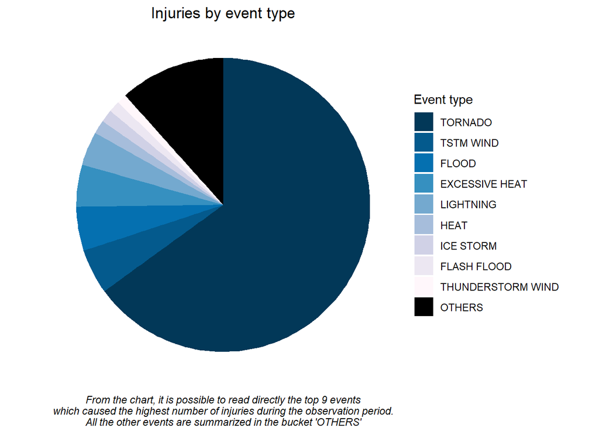

```r
ggplot(data = injuries, aes(x = "", y = total_INJURIES, fill = EVTYPE)) +
  geom_bar(stat="identity") + coord_polar("y", start = 0, direction = -1) +
  theme_void() + theme(plot.title = element_text(hjust = 0.5),
                       plot.caption=element_text(hjust = 0.5, face = "italic")) +
  scale_fill_manual(name = "Event type", values = c(rev(brewer.pal(9, "PuBu")), "#000000")) +
  labs(title = "Injuries by event type",
  caption = "From the chart, it is possible to read directly the top 9 events
which caused the highest number of injuries during the observation period.
All the other events are summarized in the bucket 'OTHERS'")
```

### Question 2: which types of events have the greatest economic consequences?

By looking at the total damage, the top-5 event types in term of impact are **FLOOD**, **HURRICANE/TYPHOON**, **TORNADO**, **STORM SURGE**, and **HAIL**.

```r
damage
```

```
## # A tibble: 10 x 4
##    EVTYPE            total_PROPDAMAGE total_CROPDAMAGE  total_DAMAGE
##    <fct>                        <dbl>            <dbl>         <dbl>
##  1 FLOOD                144657709807        5661968450 150319678257
##  2 HURRICANE/TYPHOON     69305840000        2607872800  71913712800
##  3 TORNADO               56937160779.        414953270  57352114049.
##  4 STORM SURGE           43323536000              5000  43323541000
##  5 HAIL                  15732267048.       3025954473  18758221521.
##  6 FLASH FLOOD           16140812067.       1421317100  17562129167.
##  7 DROUGHT                1046106000       13972566000  15018672000
##  8 HURRICANE             11868319010        2741910000  14610229010
##  9 RIVER FLOOD            5118945500        5029459000  10148404500
## 10 OTHERS                63187954286.      14228186088  77416140374.
```

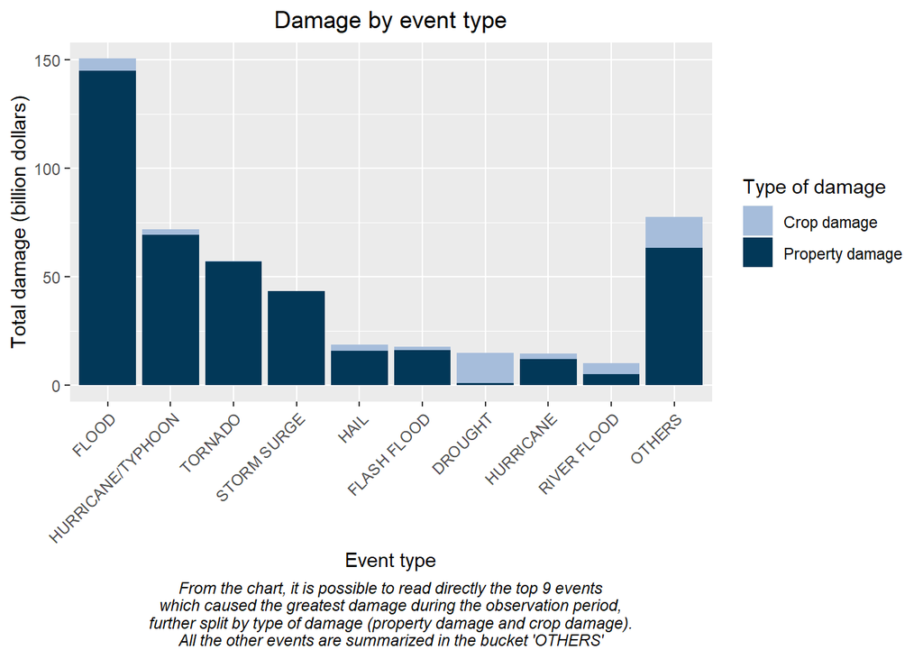

```r
damage <- damage[, c("EVTYPE", "total_PROPDAMAGE", "total_CROPDAMAGE")] %>%
  gather(key = measure, value = total, -EVTYPE)
ggplot(data = damage, aes(x = EVTYPE, y = total/1e9, fill = measure)) + geom_bar(stat="identity") +
  theme(plot.title = element_text(hjust = 0.5),
        plot.caption=element_text(hjust = 0.5, face = "italic"),
        axis.text.x = element_text(angle = 45, hjust = 1)) +
  labs(title = "Damage by event type",
  caption = "From the chart, it is possible to read directly the top 9 events
which caused the greatest damage during the observation period,
further split by type of damage (property damage and crop damage).
All the other events are summarized in the bucket 'OTHERS'") +
  xlab("Event type") + ylab("Total damage (billion dollars)") +
  scale_fill_manual(name = "Type of damage", labels = c("Crop damage", "Property damage"),
                    values = brewer.pal(9, "PuBu")[c(4,9)])
```